# OSTA5003 Week 4 Homework

Semester 1B, 2023

```
Required packages
```

```r
library(tidyverse)
library(caret)
# install.packages("glmnet")
# install.packages("ISLR")
library(glmnet)
library(ISLR)
```

# 1 Major League Baseball

The dataset we are using is one provided by the ISLR package. It contains Major League Baseball Data from the 1986 and 1987 seasons with 322 observations with 20 variables. It has some missing cases that isn’t the focus of this module and can be removed with the following code.

```r
data(Hitters, package = "ISLR")
Hitters <- na.omit(Hitters)
```

## Stepwise selection

Implement a **backward** stepwise selection procedure to remove five features. The response feature here is `Salary` which is numeric, so this is a regression and not a classification problem. Use the Root MSE as the performance metric for each selection step. Similar to the lab you may use `caret` to create a training and test split but otherwise implement the solution without using other packages (using `tidyverse` syntax is fine).

```r
## Candidate features
features <- colnames(Hitters)
features <- features[features != "Salary"]
### Assess model on all candidates
set.seed(5003)
train_indices <- createDataPartition(Hitters$Salary, p = 0.6)[[1]]
train_data <- Hitters[train_indices, ]
test_data <- Hitters[-train_indices, ]
```

```r
# Perform backward stepwise selection
model <- lm(Salary ~ ., data = train_data)
for (i in 1:5) {
  step_model <- step(model, direction = "backward")
  rmse <- sqrt(mean(step_model$residuals^2))
  cat(paste0("Removed feature ", names(coef(model))[which.max(summary(step_model)$coef[, "Pr(>|t|)"])],
            "; RMSE = ", rmse, "\n"))
  model <- step_model
}
```

```
Start:  AIC=1892.56
Salary ~ AtBat + Hits + HmRun + Runs + RBI + Walks + Years +
    CAtBat + CHits + CHmRun + CRuns + CRBI + CWalks + League +
    Division + PutOuts + Assists + Errors + NewLeague

            Df Sum of Sq      RSS    AIC
- CHmRun     1      1013 15999037 1890.6
- CAtBat     1      2979 16001003 1890.6
- League     1      4532 16002555 1890.6
- Assists    1      6339 16004363 1890.6
- NewLeague  1     11024 16009047 1890.7
- Years      1     16717 16014741 1890.7
- Errors     1     24314 16022337 1890.8
- CHits      1     39002 16037025 1891.0
- Runs       1     52549 16050573 1891.1
- HmRun      1     52573 16050597 1891.1
- CRBI       1     58146 16056170 1891.1
- RBI        1    117989 16116013 1891.7
<none>                   15998024 1892.6
- CRuns      1    333187 16331210 1893.9
- Division   1    514830 16512853 1895.7
- PutOuts    1    571414 16569438 1896.2
- AtBat      1    898168 16896192 1899.3
- Hits       1    946398 16944421 1899.8
- CWalks     1   1044604 17042627 1900.7
- Walks      1   1134195 17132219 1901.6

Step:  AIC=1890.57
Salary ~ AtBat + Hits + HmRun + Runs + RBI + Walks + Years +
    CAtBat + CHits + CRuns + CRBI + CWalks + League + Division +
    PutOuts + Assists + Errors + NewLeague

            Df Sum of Sq      RSS    AIC
- CAtBat     1      2355 16001392 1888.6
- League     1      4674 16003710 1888.6
- Assists    1      7346 16006382 1888.6
- NewLeague  1     10634 16009671 1888.7
- Years      1     17099 16016135 1888.7
- Errors     1     23709 16022746 1888.8
- Runs       1     53789 16052825 1889.1
```

[output cut: 256 more lines]

```
Start:  AIC=1876.68
Salary ~ AtBat + Hits + Walks + CRuns + CRBI + CWalks + Division +
    PutOuts

           Df Sum of Sq      RSS    AIC
<none>                  16617825 1876.7
- CRBI      1    236391 16854215 1877.0
- Division  1    522180 17140005 1879.7
- PutOuts   1    527994 17145819 1879.7
- Hits      1    937478 17555302 1883.5
- AtBat     1    954580 17572405 1883.7
- CRuns     1   1176583 17794408 1885.7
- CWalks    1   1226238 17844063 1886.1
- Walks     1   1439121 18056946 1888.0
Removed feature CRBI; RMSE = 321.272942067728
```

## Lasso regression

### Split data and fit

Split the dataset into 60% train and 40% test. Perform a lasso regression using the `glmnet` package.

```r
library(glmnet)
# Convert data.frame to a design matrix using model.matrix
# Split the dataset into 60% train and 40% test
train_idx <- sample(nrow(Hitters), round(0.6 * nrow(Hitters)))
train_data <- Hitters[train_idx, ]
test_data <- Hitters[-train_idx, ]

# Convert data.frame to a design matrix using model.matrix
train_x <- model.matrix(Salary ~., data = train_data)[,-1]
train_y <- train_data$Salary

# Fit a LASSO regression using glmnet package
lasso_model <- glmnet(train_x, train_y, alpha = 1)
```

### Inspect coefficients as function of $\lambda$

Plot the lasso regression coefficients as a function of $\lambda$. Use cross-validation to find the best $\lambda$ value (You can use the inbuilt CV function in glmnet). **Hint** The `cv.glmnet` function will return the best $\lambda$ value as `lambda.min`.

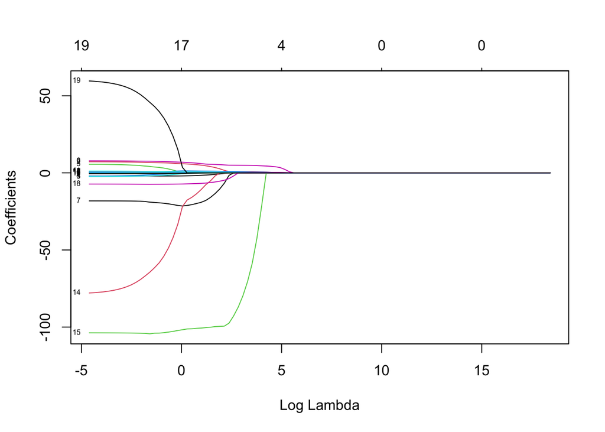

```r
# set the range of lambda values to be tested.
grid <- 10^seq(8,-2, length=100)
lasso_model <- glmnet(train_x, train_y, alpha = 1, lambda = grid)

# Inspect coefficients as a function of lambda
plot(lasso_model, xvar = "lambda", label = TRUE)
```

```r
# Use cross-validation to find the best lambda value
cv_model <- cv.glmnet(train_x, train_y, alpha = 1, lambda = grid)
best_lambda <- cv_model$lambda.min
```

### Check if model is sparse

Inspect the coefficients in the best model above and check if there there are any coefficients that have been shrunk to zero. **Hint** The `cv.glmnet` will also return the model fits for each $\lambda$ value. You can extract the coefficients for each $\lambda$ value using `cv.out$glmnet.fit$beta`.

```r
best_lambda <- cv_model$lambda.min

# Check if the model is sparse
coef(lasso_model, s = best_lambda)
```

```
20 x 1 sparse Matrix of class "dgCMatrix"
                     s1
(Intercept) -32.2336912
AtBat         .
Hits          0.8220093
HmRun         .
Runs          .
RBI           .
Walks         4.9400234
Years         .
CAtBat        .
CHits         .
CHmRun        0.8096039
CRuns         0.1940235
CRBI          0.2861728
CWalks        .
LeagueN       .
DivisionW   -86.9549820
PutOuts       0.2736404
Assists       0.1447941
Errors        .
NewLeagueN    .
```

```r
# Inspect the coefficients in the best model
best_coef <- coef(cv_model, s = best_lambda)
print(best_coef)
```

```
20 x 1 sparse Matrix of class "dgCMatrix"
                     s1
(Intercept) -32.2336912
AtBat         .
Hits          0.8220093
HmRun         .
Runs          .
RBI           .
Walks         4.9400234
Years         .
CAtBat        .
CHits         .
CHmRun        0.8096039
CRuns         0.1940235
CRBI          0.2861728
CWalks        .
LeagueN       .
DivisionW   -86.9549820
PutOuts       0.2736404
Assists       0.1447941
Errors        .
NewLeagueN    .
```

### Assess on the test set

Using the optimal trained model predict the salary of the test dataset and calculate the mean squared error.

```r
# Use the best CV model to predict the test set Salary

# Assess the model on the test set
test_x <- model.matrix(Salary ~., data = test_data)[, -1]
test_y <- test_data$Salary

lasso_pred <- predict(lasso_model, newx = test_x, s = best_lambda)
MSE <- mean((test_y - lasso_pred)^2)
MSE
```

```
[1] 112162.9
```